# Asutuste teenuste juhtimise küpsustase

Risto Hinno

detsember 2015

## Sissejuhatus

Käesolev artikkel üritab numbriliselt näidata, milline on Eesti avaliku sektori asutuste teenuste juhtimise küpsustase. Kuna [projekt](https://github.com/MKM-ITAO/riigiteenused) alles käib, on tulemused poolikud ning põhjapanevate järelduste tegemine jääb 2016. aasta märtsi, kui peaks kõik teenused olema kaardistatud. Analüüsitavad andmed tõmmati veebist seisuga 2015-12-22 17:21:45.

## Teenuste juhtimise küpsustasemest

Teenuste küpsustasemetest räägib [“Teenuste portfellijuhtimise uuring”](https://www.mkm.ee/sites/default/files/avalike_teenuste_uhtne_portfellijuhtimine.pdf) lehekülg 11. Teenuse juhtimise küpsusmudel aitab hinata, mis tasemel asutus teenuseid juhib ning aitab ka disainida meetmeid, kuidas asutusi mõjutada küpsustaset tõstma.Üldjoontes on tasemed järgmised:

- **1. Funktsioon** (teenuste kirjeldamine puudub, täidetakse ainult seadusest tulenevaid funktsioone),
- **2. Teenuste loend** (eksisteerib teenuste loend, nagu näiteks [siin](https://www.mkm.ee/et/teenuste-otsing)),
- **3. Kirjeldatud teenus** (teenuse info on korrastatud, teenusel on omanik),
- **4. Mõõdetud teenus** (teenusel on mõõdik, teenuse kohta tehakse analüüsi),
- **5. Optimeeritud teenus** (toimub teenuste teadlik ja pidev parendamine, teenused on seostatud riigi strateegilise juhtimise mõõdikutega)

## Hetkeolukord

Hetkeolukorra hindamiseks kasutan riigiteenuste projekti andmeid (masinloetaval kujul kättesaadavad [siin](https://www.riigiteenused.ee/api/et/all)).

Protsess küpsustaseme arvutamiseks on lihtne ning kujutatud järgneval joonisel:

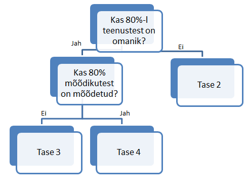

80% reegel on võetud ärimaailmas käibes olevast 80/20 põhimõttest. 100%-lise täitmise seadmine on ebamõistlik, kuna marginaalsete teenuste puhul on omanike puudumine või mõõdikute mittemõõtmine ebaoluline. Põhirõhk peab olema olulistel (suurimat väärtust loovatel) teenustel. Lisaks võib mõõdikute puudumine/omaniku puudumine olla seotud ümberkorraldustega teenuste/asutuse juhtimisel.

## Tulemused

Ministeeriumite lõikes on teenuste juhtimise küpsustasemed järgnevad:

Vaatame kõige pealt, mis on ministeeriumite haldusalade teenuste juhtimise küpsustase:

| Ministeerium | Teenuste arv | Küpsustase |
| --- | --- | --- |
| Haridus- ja Teadusministeeriumi haldusala | 38 | 2 |
| Justiitsministeeriumi haldusala | 19 | 2 |
| Keskkonnaministeeriumi haldusala | 12 | 3 |
| Kultuuriministeeriumi haldusala | 12 | 2 |
| Maaeluministeeriumi haldusala | 7 | 3 |
| Majandus- ja Kommunikatsiooniministeeriumi haldusala | 218 | 2 |
| Rahandusministeeriumi haldusala | 53 | 3 |
| Siseministeeriumi haldusala | 1 | 2 |
| Sotsiaalministeeriumi haldusala | 10 | 3 |
| Välisministeeriumi haldusala | 10 | 3 |

Vaatame, kas asutuste lõikes on olukord erinev.

| Ministeerium | Allasutus | Teenuste arv | Küpsustase |
| --- | --- | --- | --- |
| Haridus- ja Teadusministeeriumi haldusala | Eesti Noorsootöö Keskus | 3 | 3 |
| Haridus- ja Teadusministeeriumi haldusala | Haridus- ja Teadusministeerium | 7 | 3 |
| Haridus- ja Teadusministeeriumi haldusala | Keeleinspektsioon | 6 | 3 |
| Haridus- ja Teadusministeeriumi haldusala | Rahvusarhiiv | 17 | 2 |
| Haridus- ja Teadusministeeriumi haldusala | Sihtasutus Innove | 5 | 3 |
| Justiitsministeeriumi haldusala | Eesti Kohtuekspertiisi Instituut | 1 | 2 |
| Justiitsministeeriumi haldusala | Justiitsministeerium | 7 | 3 |
| Justiitsministeeriumi haldusala | Konkurentsiamet | 11 | 2 |
| Keskkonnaministeeriumi haldusala | Keskkonnaamet | 12 | 3 |
| Kultuuriministeeriumi haldusala | Eesti Arhitektuurimuuseum | 10 | 2 |
| Kultuuriministeeriumi haldusala | Eesti Rahvusringhääling | 1 | 3 |
| Kultuuriministeeriumi haldusala | Kultuuriministeerium | 1 | 3 |
| Maaeluministeeriumi haldusala | Maaeluministeerium | 7 | 3 |
| Majandus- ja Kommunikatsiooniministeeriumi haldusala | Lennuamet | 24 | 2 |
| Majandus- ja Kommunikatsiooniministeeriumi haldusala | Maanteeamet | 14 | 3 |
| Majandus- ja Kommunikatsiooniministeeriumi haldusala | Majandus- ja Kommunikatsiooniministeerium | 21 | 2 |
| Majandus- ja Kommunikatsiooniministeeriumi haldusala | Riigi Infosüsteemi Amet (RIA) | 27 | 2 |
| Majandus- ja Kommunikatsiooniministeeriumi haldusala | Tarbijakaitseamet | 1 | 3 |
| Majandus- ja Kommunikatsiooniministeeriumi haldusala | Tehnilise Järelevalve Amet | 79 | 2 |
| Majandus- ja Kommunikatsiooniministeeriumi haldusala | Veeteede Amet | 52 | 2 |
| Rahandusministeeriumi haldusala | Maksu- ja Tolliamet | 1 | 2 |
| Rahandusministeeriumi haldusala | Rahandusministeerium | 4 | 2 |
| Rahandusministeeriumi haldusala | Riigi Tugiteenuste Keskusest | 1 | 3 |
| Rahandusministeeriumi haldusala | Statistikaamet | 23 | 3 |
| Rahandusministeeriumi haldusala | Tartu Maavalitsus | 24 | 3 |
| Siseministeeriumi haldusala | Päästeamet | 1 | 2 |
| Sotsiaalministeeriumi haldusala | Sotsiaalkindlustusamet | 10 | 3 |
| Välisministeeriumi haldusala | Välisministeerium | 10 | 3 |

Nagu näha võib näha mitmeid asutusi, kes teenuste juhtimine on tasemel 3. Samas tuleb hetkel olla tulemuste suhtes kriitiline, kuna paljudes asutustes on enamik teenuseid kirjeldamata. Kõikide teenuste kirjeldamisel saab adekvaatsema ülevaate, mis teenuste küpsustase. Kui sind huvitab selle artikli tulemuste saamiseks kasutatav R-i kood, kliki [siia](https://github.com/RRisto/Teenuste_kupsus/tree/master).